# Analysing Chopstick Length

## Descriptive and Inferential Statistics Project

#### Data Analyst Nanodegree (Udacity)

Project submission by Edward Minnett (ed@methodic.io).

February 29th 2016. (Revision 2)

## Chopsticks!

A few researchers set out to determine the optimal length of chopsticks for children and adults. They came up with a measure of how effective a pair of chopsticks performed, called the "Food Pinching Performance." The "Food Pinching Performance" was determined by counting the number of peanuts picked and placed in a cup (PPPC).

### An investigation for determining the optimum length of chopsticks.

[Link to Abstract and Paper](http://www.ncbi.nlm.nih.gov/pubmed/15676839)  
*the abstract below was adapted from the link*

Chopsticks are one of the most simple and popular hand tools ever invented by humans, but have not previously been investigated by ergonomists. Two laboratory studies were conducted in this research, using a [randomised complete block design](http://dawg.utk.edu/glossary/whatis_rcbd.htm), to evaluate the effects of the length of the chopsticks on the food-serving performance of adults and children. Thirty-one male junior college students and 21 primary school pupils served as subjects for the experiment to test chopsticks lengths of 180, 210, 240, 270, 300, and 330 mm. The results showed that the food-pinching performance was significantly affected by the length of the chopsticks, and that chopsticks of about 240 and 180 mm long were optimal for adults and pupils, respectively. Based on these findings, the researchers suggested that families with children should provide both 240 and 180 mm long chopsticks. In addition, restaurants could provide 210 mm long chopsticks, considering the trade-offs between ergonomics and cost.

### For the rest of this project, answer all questions based only on the part of the experiment analyzing the thirty-one adult male college students.

Download the [data set for the adults](https://www.udacity.com/api/nodes/4576183932/supplemental_media/chopstick-effectivenesscsv/download), then answer the following questions based on the abstract and the data set.

**If you double click on this cell**, you will see the text change so that all of the formatting is removed. This allows you to edit this block of text. This block of text is written using [Markdown](http://daringfireball.net/projects/markdown/syntax), which is a way to format text using headers, links, italics, and many other options. You will learn more about Markdown later in the Nanodegree Program. Hit shift + enter or shift + return to show the formatted text.

## 1. What is the independent variable in the experiment?

You can either double click on this cell to add your answer in this cell, or use the plus sign in the toolbar (Insert cell below) to add your answer in a new cell.

The independent variable in this experiment is the chopsticks length (from 180mm to 330 mm).

#### 2. What is the dependent variable in the experiment?

The dependent variable in this experiment is the 'Food Pinching Performance' experinced by the subjects.

#### 3. How is the dependent variable operationally defined?

The dependent variable, 'Food Pinching Performance', is operationally defined as the number of peanuts picked up and placed in a cup (PPPC).

#### 4. Based on the description of the experiment and the data set, list at least two variables that you know were controlled.

Think about the participants who generated the data and what they have in common. You don't need to guess any variables or read the full paper to determine these variables. (For example, it seems plausible that the material of the chopsticks was held constant, but this is not stated in the abstract or data description.)

Even though there were two studies conducted (a study on adults and a study on children), there were some variables held constant within these groups. The abstract specifically states that the adult subjects are male. This would help maintain consistency of hand size, and perhaps to a lesser extent, hand dexterity. It is not clear whether the gender of the child subjects was also held constant. Within each group the source of subjects, junior college for the adults and primary school for the children, suggests that the age range of subjects within each group is held relatively constant (at least within a few years fo each other). Though details are not given, the use of a randomised complete block design suggests that environmental factors present while conducting the study are held constant within the context of each block of subjects. This experimental design would help reduce noise within the dataset that could have introduced bias in the results.

One great advantage of ipython notebooks is that you can document your data analysis using code, add comments to the code, or even add blocks of text using Markdown. These notebooks allow you to collaborate with others and share your work. For now, let's see some code for doing statistics.

```python
import pandas as pd

# pandas is a software library for data manipulation and analysis
# We commonly use shorter nicknames for certain packages. Pandas is often abbreviated to pd.
# hit shift + enter to run this cell or block of code
```

```python
path = r'./chopstick-effectiveness.csv'
# Change the path to the location where the chopstick-effectiveness.csv file is located on your computer.
# If you get an error when running this block of code, be sure the chopstick-effectiveness.csv is located at
# the path on your computer.

dataFrame = pd.read_csv(path)
dataFrame
```

|  | Food.Pinching.Efficiency | Individual | Chopstick.Length |
| --- | --- | --- | --- |
| 0 | 19.55 | 1 | 180 |
| 1 | 27.24 | 2 | 180 |
| 2 | 28.76 | 3 | 180 |
| 3 | 31.19 | 4 | 180 |
| 4 | 21.91 | 5 | 180 |
| 5 | 27.62 | 6 | 180 |
| 6 | 29.46 | 7 | 180 |
| 7 | 26.35 | 8 | 180 |
| 8 | 26.69 | 9 | 180 |
| 9 | 30.22 | 10 | 180 |
| 10 | 27.81 | 11 | 180 |
| 11 | 23.46 | 12 | 180 |
| 12 | 23.64 | 13 | 180 |
| 13 | 27.85 | 14 | 180 |
| 14 | 20.62 | 15 | 180 |
| 15 | 25.35 | 16 | 180 |
| 16 | 28.00 | 17 | 180 |
| 17 | 23.49 | 18 | 180 |
| 18 | 27.77 | 19 | 180 |
| 19 | 18.48 | 20 | 180 |
| 20 | 23.01 | 21 | 180 |
| 21 | 22.66 | 22 | 180 |
| 22 | 23.24 | 23 | 180 |
| 23 | 22.82 | 24 | 180 |
| 24 | 17.94 | 25 | 180 |
| 25 | 26.67 | 26 | 180 |
| 26 | 28.98 | 27 | 180 |
| 27 | 21.48 | 28 | 180 |
| 28 | 14.47 | 29 | 180 |
| 29 | 28.29 | 30 | 180 |
| ... | ... | ... | ... |
| 156 | 26.18 | 2 | 330 |
| 157 | 25.93 | 3 | 330 |
| 158 | 28.61 | 4 | 330 |
| 159 | 20.54 | 5 | 330 |
| 160 | 26.44 | 6 | 330 |
| 161 | 29.36 | 7 | 330 |
| 162 | 19.77 | 8 | 330 |
| 163 | 31.69 | 9 | 330 |
| 164 | 24.64 | 10 | 330 |
| 165 | 22.09 | 11 | 330 |
| 166 | 23.42 | 12 | 330 |
| 167 | 28.63 | 13 | 330 |
| 168 | 26.30 | 14 | 330 |
| 169 | 22.89 | 15 | 330 |
| 170 | 22.68 | 16 | 330 |
| 171 | 30.92 | 17 | 330 |
| 172 | 20.74 | 18 | 330 |
| 173 | 27.24 | 19 | 330 |
| 174 | 17.12 | 20 | 330 |
| 175 | 23.63 | 21 | 330 |
| 176 | 20.91 | 22 | 330 |
| 177 | 23.49 | 23 | 330 |
| 178 | 24.86 | 24 | 330 |
| 179 | 16.28 | 25 | 330 |
| 180 | 21.52 | 26 | 330 |
| 181 | 27.22 | 27 | 330 |
| 182 | 17.41 | 28 | 330 |
| 183 | 16.42 | 29 | 330 |
| 184 | 28.22 | 30 | 330 |
| 185 | 27.52 | 31 | 330 |

186 rows × 3 columns

Let's do a basic statistical calculation on the data using code! Run the block of code below to calculate the average "Food Pinching Efficiency" for all 31 participants and all chopstick lengths.

```python
dataFrame['Food.Pinching.Efficiency'].mean()
```

```
25.00559139784947
```

This number is helpful, but the number doesn't let us know which of the chopstick lengths performed best for the thirty-one male junior college students. Let's break down the data by chopstick length. The next block of code will generate the average "Food Pinching Effeciency" for each chopstick length. Run the block of code below.

```python
meansByChopstickLength = dataFrame.groupby('Chopstick.Length')['Food.Pinching.Efficiency'].mean().reset_index()
meansByChopstickLength

# reset_index() changes Chopstick.Length from an index to column. Instead of the index being the length of the
# chopsticks, the index is the row numbers 0, 1, 2, 3, 4, 5.
```

|  | Chopstick.Length | Food.Pinching.Efficiency |
| --- | --- | --- |
| 0 | 180 | 24.935161 |
| 1 | 210 | 25.483871 |
| 2 | 240 | 26.322903 |
| 3 | 270 | 24.323871 |
| 4 | 300 | 24.968065 |
| 5 | 330 | 23.999677 |

#### 5. Which chopstick length performed the best for the group of thirty-one male junior college students?

```python
# The answer is clearly 240mm, but it is nice to answer these sorts of questions abstractly in case we choose to
# change the analysis that produced the table.
max_fpe_mean = max(meansByChopstickLength['Food.Pinching.Efficiency'])
chopstick_length_with_max_mean = [length for (length, mean) in meansByChopstickLength.values if mean == max_fpe_mean][0]
print 'The chopstick length with the best mean performance is ' + str(chopstick_length_with_max_mean) + 'mm.'
```

```
The chopstick length with the best mean performance is 240.0mm.
```

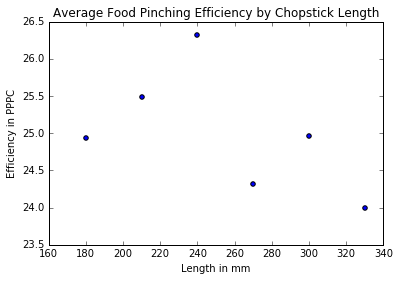

```python
# Causes plots to display within the notebook rather than in a new window
%matplotlib inline

import matplotlib.pyplot as plt

plt.scatter(x=meansByChopstickLength['Chopstick.Length'], y=meansByChopstickLength['Food.Pinching.Efficiency'])
            # title="")
plt.xlabel("Length in mm")
plt.ylabel("Efficiency in PPPC")
plt.title("Average Food Pinching Efficiency by Chopstick Length")
plt.show()
```

#### 6. Based on the scatterplot created from the code above, interpret the relationship you see. What do you notice?

The rough shape of scatter plot above is that of an inverted parabola with a maximum at 240mm. That said, ther are too few points to feel confident about this interpretation. More specifically it appears that chopsticks that are too long have a more detrimental effect on 'Food Pinching Performance' than chopsticks that are too short. Again it is hard to be confident that these trends are indicative of the true nature of 'Food Pinching Performance' and not simply noise in the samples without doing further analysis.

### In the abstract the researchers stated that their results showed food-pinching performance was significantly affected by the length of the chopsticks, and that chopsticks of about 240 mm long were optimal for adults.

#### 7a. Based on the data you have analyzed, do you agree with the claim?

#### 7b. Why?

The trouble with answering these questions without doing further analysis is agreeing or disagreeing with the phrase 'significantly affected'. The term 'significance' carries specific meaning when discussing statistics. To decide whether the resulst are indeed significant, I feel compelled to calculate the F score using repeated measures ANOVA.

We will consider an alpha level of 0.05 to be the threshold of significance for this test.

The accuracy of the Repeated Measures ANOVA F statistic is predecated upon two assumptions. It requires that the distribution of sample values for each treatment be normal in shape. It also requires that the data pass a Sphericity Test (in this case, Bartlett's Test).

### Testing Normality

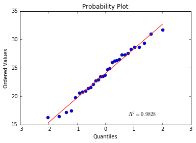

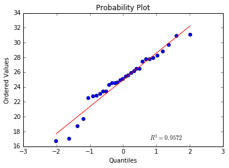

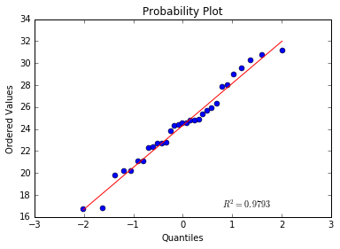

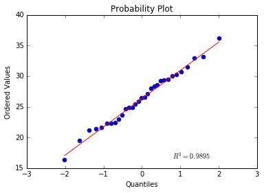

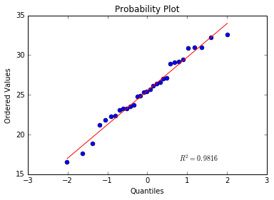

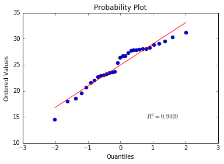

```python
import scipy.stats as stats

grouped_by_chopstick_length = dataFrame.groupby('Chopstick.Length')

for chopstick_length in grouped_by_chopstick_length.groups.keys():
    plt.figure()
    stats.probplot(grouped_by_chopstick_length.get_group(chopstick_length)['Food.Pinching.Efficiency'], dist="norm", plot=plt)
    plt.show()
```

By using the [Q-Q plots](https://en.wikipedia.org/wiki/Q%E2%80%93Q_plot), we are able determine how well a normal distribution models the data for each chopstick length. Given that the smallest R^2 value is 0.9449, the assumption that each treatment is normal in shape is acceptable.

### Testing Sphericity

```python
import numpy as np

choptick_lengths = grouped_by_chopstick_length.groups.keys()

grouped_by_length_data = []
for chopstic_length in choptick_lengths:
    grouped_by_length_data.append(np.array(grouped_by_chopstick_length.get_group(chopstic_length)['Food.Pinching.Efficiency']))

stats.bartlett(*grouped_by_length_data)
```

```
BartlettResult(statistic=1.9894577367822801, pvalue=0.8506018295183877)
```

The Bartlett Test determines the p value for a hypothesis test where H0 represents the belief that the data for each treament are samples from populations with equal variance. The alternative hypothesis is that at least two of the sampel variances are not equal. This test has resulted in a very high p value (0.85) meaning we fail to reject the null hypoethesis. This in turn confirms that the data does not violate sphericity.

Now that we have validated the assumptions, we can continue with the Repeated Measures ANOVA.

### Repeated Measures ANOVA

```python
# This process follows this guide https://statistics.laerd.com/statistical-guides/repeated-measures-anova-statistical-guide.php

grouped_by_individuals = dataFrame.groupby('Individual')

num_interventions = len(grouped_by_chopstick_length)
num_subjects = len(grouped_by_individuals)

intervention_means = grouped_by_chopstick_length['Food.Pinching.Efficiency'].mean()
subject_means = grouped_by_individuals['Food.Pinching.Efficiency'].mean()
global_mean = dataFrame['Food.Pinching.Efficiency'].mean()

ss_between = num_subjects * intervention_means.apply(lambda x_bar: (x_bar - global_mean)**2).sum()
ss_within = sum([(r[0] - intervention_means[int(r[2])])**2 for r in dataFrame.values])
ss_subjects = num_interventions * subject_means.apply(lambda x_bar: (x_bar - global_mean)**2).sum()
ss_error = ss_within - ss_subjects

df_between = num_interventions - 1
df_error = (num_subjects - 1) * (num_interventions - 1)

ms_between = ss_between / df_between
ms_error = ss_error / df_error

F = ms_between / ms_error

p_value = stats.f.pdf(F, df_between, df_error)

print p_value
```

```
0.000500479118293
```

```python
print ("The p value " + str(p_value) + " for the F statistic " + str(F) + " with " +
    "degrees of freedom (" + str(df_between) + ", " + str(df_error)+ ") is considerably less than the 0.05 alpha level.")
```

```
The p value 0.000500479118293 for the F statistic 5.0513262437 with degrees of freedom (5, 150) is considerably less than the 0.05 alpha level.
```

The fact that the p value is less than the alpha level, we reject the null hypothesis and satisfactorily accept the claim that the length of the chopsticks in this study make a significant enough impact on the Food Pinching Efficiency as defined as the number of peanuts picked up and placed in a cup (PPPC).

**7A**: I agree with the statement that 'food-pinching performance was significantly affected by the length of the chopsticks'.

**7B**: The F statistic calculated useing repeated Measures ANOVA above indicates that the results of the 'An investigation for determining the optimum length of chopsticks.' study for the sample of adult males is significant enough to reject the null hypothesis thus suggesting the population means of Food Pinching Performance are not all the same for all of the chopstick lengths used in the study.